## Atenciones de cobertura oncológica 2022 - 2023

**Objetivo**: Analizar las atenciones oncológicas registradas por el Fondo Intangible Solidario de Salud (FISSAL) durante los periodos 2022 y 2023, con el propósito de identificar patrones en la distribución de casos según sexo, edad, tipo de cáncer y monto de cobertura, a fin de contribuir al conocimiento de la situación oncológica nacional y orientar estrategias de prevención, diagnóstico temprano y asignación equitativa de recursos en el sistema de salud peruano.

**Fuente de los datos**: https://www.datosabiertos.gob.pe/dataset/atenciones-de-cobertura-oncol%C3%B3gica-periodos-2022-2023-fondo-intangible-solidario-de-salud

**Colores para los gráficos**: https://r-charts.com/colors/

**Importación de las librerías:**

```r
library(ggplot2)
library(magrittr)
library(dplyr)
library(markdown)
library(tidyverse)
library(readr)
```

**Importación y unión de los archivos:**

```r
dataonco <- read_csv2("/Users/vany/Documents/O_P/Projets/Data_cancer_seguroonco/dataatenciones_2022.csv",col_names = TRUE)
```

```
## ℹ Using "','" as decimal and "'.'" as grouping mark. Use `read_delim()` for more control.
```

```r
data2onco <- read_csv2("/Users/vany/Documents/O_P/Projets/Data_cancer_seguroonco/dataset2023.csv",col_names = TRUE)
```

```
## ℹ Using "','" as decimal and "'.'" as grouping mark. Use `read_delim()` for more control.
```

```r
datafonco <- rbind(dataonco,data2onco)
```

Utilicé la ruta /Users/vany y el “read_csv2” para que acepte el “;” de lo contrario utilizaría el read_csv. Otra opción es el read.csv.

**Vista general de los datos:**

```r
summary(datafonco)
```

```
##  DOCUMENTO_ANONIMIZADO    PERIODO          RENAES             IPRESS
##  Length:820675         Min.   :202201   Length:820675      Length:820675
##  Class :character      1st Qu.:202206   Class :character   Class :character
##  Mode  :character      Median :202210   Mode  :character   Mode  :character
##                        Mean   :202243
##                        3rd Qu.:202303
##                        Max.   :202306
##
##     REGION          DEPARTAMENTO        PROVINCIA           DISTRITO
##  Length:820675      Length:820675      Length:820675      Length:820675
##  Class :character   Class :character   Class :character   Class :character
##  Mode  :character   Mode  :character   Mode  :character   Mode  :character
##
##
##
##
##     UBIGEO          CODIGO_DIAGNOSTICO DIAGNOSTICOS       GRUPO_DIAGNOSTICOS
##  Length:820675      Length:820675      Length:820675      Length:820675
##  Class :character   Class :character   Class :character   Class :character
##  Mode  :character   Mode  :character   Mode  :character   Mode  :character
##
##
##
##
##  GRUPO_COBERTURA        SEXO                EDAD        TIPO_SEGURO
##  Length:820675      Length:820675      Min.   :  0.00   Length:820675
##  Class :character   Class :character   1st Qu.: 42.00   Class :character
##  Mode  :character   Mode  :character   Median : 54.00   Mode  :character
##                                        Mean   : 51.83
##                                        3rd Qu.: 66.00
##                                        Max.   :106.00
##
##  CODIGO_SERVICIO      SERVICIO         FECHA_ATENCION     FECHA_INTERNAMIENTO
##  Length:820675      Length:820675      Min.   :20210714   Min.   :20210106
##  Class :character   Class :character   1st Qu.:20220510   1st Qu.:20220121
##  Mode  :character   Mode  :character   Median :20220924   Median :20220329
##                                        Mean   :20223353   Mean   :20219593
##                                        3rd Qu.:20230207   3rd Qu.:20220603
##                                        Max.   :20230630   Max.   :20230627
##                                                           NA's   :747670
##    FECHA_ALTA       MONTO_BRUTO         FECHA_CORTE
##  Min.   :20210819   Length:820675      Min.   :20230525
##  1st Qu.:20220414   Class :character   1st Qu.:20230525
##  Median :20220903   Mode  :character   Median :20230525
##  Mean   :20222606                      Mean   :20230745
##  3rd Qu.:20230117                      3rd Qu.:20231113
##  Max.   :20230629                      Max.   :20231113
##  NA's   :658789
```

```r
head(datafonco)
```

```
## # A tibble: 6 × 23
##   DOCUMENTO_ANONIMIZADO PERIODO RENAES   IPRESS    REGION DEPARTAMENTO PROVINCIA
##   <chr>                   <dbl> <chr>    <chr>     <chr>  <chr>        <chr>
## 1 05060                  202212 00006210 INSTITUT… LIMA   Lima         Lima
## 2 05060                  202212 00006210 INSTITUT… LIMA   Lima         Lima
## 3 112180                 202207 00006210 INSTITUT… LIMA   Lima         Lima
## 4 112180                 202212 00006211 HOSPITAL… LIMA   Lima         Lima
## 5 112180                 202212 00006211 HOSPITAL… LIMA   Lima         Lima
## 6 112180                 202212 00006211 HOSPITAL… LIMA   Lima         Lima
## # ℹ 16 more variables: DISTRITO <chr>, UBIGEO <chr>, CODIGO_DIAGNOSTICO <chr>,
## #   DIAGNOSTICOS <chr>, GRUPO_DIAGNOSTICOS <chr>, GRUPO_COBERTURA <chr>,
## #   SEXO <chr>, EDAD <dbl>, TIPO_SEGURO <chr>, CODIGO_SERVICIO <chr>,
## #   SERVICIO <chr>, FECHA_ATENCION <dbl>, FECHA_INTERNAMIENTO <dbl>,
## #   FECHA_ALTA <dbl>, MONTO_BRUTO <chr>, FECHA_CORTE <dbl>
```

**Encabezados:**

```r
colnames(datafonco)
```

```
##  [1] "DOCUMENTO_ANONIMIZADO" "PERIODO"               "RENAES"
##  [4] "IPRESS"                "REGION"                "DEPARTAMENTO"
##  [7] "PROVINCIA"             "DISTRITO"              "UBIGEO"
## [10] "CODIGO_DIAGNOSTICO"    "DIAGNOSTICOS"          "GRUPO_DIAGNOSTICOS"
## [13] "GRUPO_COBERTURA"       "SEXO"                  "EDAD"
## [16] "TIPO_SEGURO"           "CODIGO_SERVICIO"       "SERVICIO"
## [19] "FECHA_ATENCION"        "FECHA_INTERNAMIENTO"   "FECHA_ALTA"
## [22] "MONTO_BRUTO"           "FECHA_CORTE"
```

**Los tipos de datos:**

```r
str(datafonco)
```

```
## spc_tbl_ [820,675 × 23] (S3: spec_tbl_df/tbl_df/tbl/data.frame)
##  $ DOCUMENTO_ANONIMIZADO: chr [1:820675] "05060" "05060" "112180" "112180" ...
##  $ PERIODO              : num [1:820675] 202212 202212 202207 202212 202212 ...
##  $ RENAES               : chr [1:820675] "00006210" "00006210" "00006210" "00006211" ...
##  $ IPRESS               : chr [1:820675] "INSTITUTO NACIONAL DE ENFERMEDADES NEOPLASICAS - INEN" "INSTITUTO NACIONAL DE ENFERMEDADES NEOPLASICAS - INEN" "INSTITUTO NACIONAL DE ENFERMEDADES NEOPLASICAS - INEN" "HOSPITAL DE APOYO SANTA ROSA" ...
##  $ REGION               : chr [1:820675] "LIMA" "LIMA" "LIMA" "LIMA" ...
##  $ DEPARTAMENTO         : chr [1:820675] "Lima" "Lima" "Lima" "Lima" ...
##  $ PROVINCIA            : chr [1:820675] "Lima" "Lima" "Lima" "Lima" ...
##  $ DISTRITO             : chr [1:820675] "Surquillo" "Surquillo" "Surquillo" "Pueblo Libre" ...
##  $ UBIGEO               : chr [1:820675] "150141" "150141" "150141" "150121" ...
##  $ CODIGO_DIAGNOSTICO   : chr [1:820675] "C539" "C539" "C169" "C169" ...
##  $ DIAGNOSTICOS         : chr [1:820675] "TUMOR MALIGNO DEL CUELLO DEL UTERO, SIN OTRA ESPECIFICACION" "TUMOR MALIGNO DEL CUELLO DEL UTERO, SIN OTRA ESPECIFICACION" "TUMOR MALIGNO DEL ESTOMAGO, PARTE NO ESPECIFICADA" "TUMOR MALIGNO DEL ESTOMAGO, PARTE NO ESPECIFICADA" ...
##  $ GRUPO_DIAGNOSTICOS   : chr [1:820675] "CANCER DE CUELLO UTERINO" "CANCER DE CUELLO UTERINO" "CANCER DE ESTOMAGO" "CANCER DE ESTOMAGO" ...
##  $ GRUPO_COBERTURA      : chr [1:820675] "ONCOLOGICAS" "ONCOLOGICAS" "ONCOLOGICAS" "ONCOLOGICAS" ...
##  $ SEXO                 : chr [1:820675] "FEMENINO" "FEMENINO" "MASCULINO" "MASCULINO" ...
##  $ EDAD                 : num [1:820675] 62 61 73 73 73 73 73 73 73 73 ...
##  $ TIPO_SEGURO          : chr [1:820675] "SIS GRATUITO" "SIS GRATUITO" "SIS INDEPENDIENTE" "SIS INDEPENDIENTE" ...
##  $ CODIGO_SERVICIO      : chr [1:820675] "909" "056" "071" "056" ...
##  $ SERVICIO             : chr [1:820675] "Teleorientación" "Consulta externa" "Apoyo al diagnóstico (*)" "Consulta externa" ...
##  $ FECHA_ATENCION       : num [1:820675] 20221201 20221115 20220628 20221111 20221130 ...
##  $ FECHA_INTERNAMIENTO  : num [1:820675] NA NA NA NA NA NA NA NA NA NA ...
##  $ FECHA_ALTA           : num [1:820675] NA NA NA NA NA NA NA NA NA NA ...
##  $ MONTO_BRUTO          : chr [1:820675] "0.0000" "5.9200" "222.0400" "23.4500" ...
##  $ FECHA_CORTE          : num [1:820675] 20230525 20230525 20230525 20230525 20230525 ...
##  - attr(*, "spec")=
##   .. cols(
##   ..   DOCUMENTO_ANONIMIZADO = col_character(),
##   ..   PERIODO = col_double(),
##   ..   RENAES = col_character(),
##   ..   IPRESS = col_character(),
##   ..   REGION = col_character(),
##   ..   DEPARTAMENTO = col_character(),
##   ..   PROVINCIA = col_character(),
##   ..   DISTRITO = col_character(),
##   ..   UBIGEO = col_character(),
##   ..   CODIGO_DIAGNOSTICO = col_character(),
##   ..   DIAGNOSTICOS = col_character(),
##   ..   GRUPO_DIAGNOSTICOS = col_character(),
##   ..   GRUPO_COBERTURA = col_character(),
##   ..   SEXO = col_character(),
##   ..   EDAD = col_double(),
##   ..   TIPO_SEGURO = col_character(),
##   ..   CODIGO_SERVICIO = col_character(),
##   ..   SERVICIO = col_character(),
##   ..   FECHA_ATENCION = col_double(),
##   ..   FECHA_INTERNAMIENTO = col_double(),
##   ..   FECHA_ALTA = col_double(),
##   ..   MONTO_BRUTO = col_character(),
##   ..   FECHA_CORTE = col_double()
##   .. )
##  - attr(*, "problems")=<externalptr>
```

**Cambio de los tipos de datos:**

```r
datafonco$MONTO_BRUTO <- as.numeric(datafonco$MONTO_BRUTO)
datafonco$PERIODO <- as.character(datafonco$PERIODO)
datafonco$FECHA_ATENCION  <- as.character(datafonco$FECHA_ATENCION)
datafonco$FECHA_INTERNAMIENTO <- as.character(datafonco$FECHA_INTERNAMIENTO)
datafonco$FECHA_ALTA<- as.character(datafonco$FECHA_ALTA)
datafonco$FECHA_CORTE <- as.character(datafonco$FECHA_CORTE)
```

**Verificación de los tipos de datos:**

```r
typeof(datafonco$MONTO_BRUTO)
```

```
## [1] "double"
```

```r
typeof(datafonco$PERIODO)
```

```
## [1] "character"
```

```r
typeof(datafonco$FECHA_ATENCION)
```

```
## [1] "character"
```

```r
typeof(datafonco$FECHA_INTERNAMIENTO)
```

```
## [1] "character"
```

```r
typeof(datafonco$FECHA_ALTA)
```

```
## [1] "character"
```

```r
typeof(datafonco$FECHA_CORTE)
```

```
## [1] "character"
```

**Histograma de la edad:**

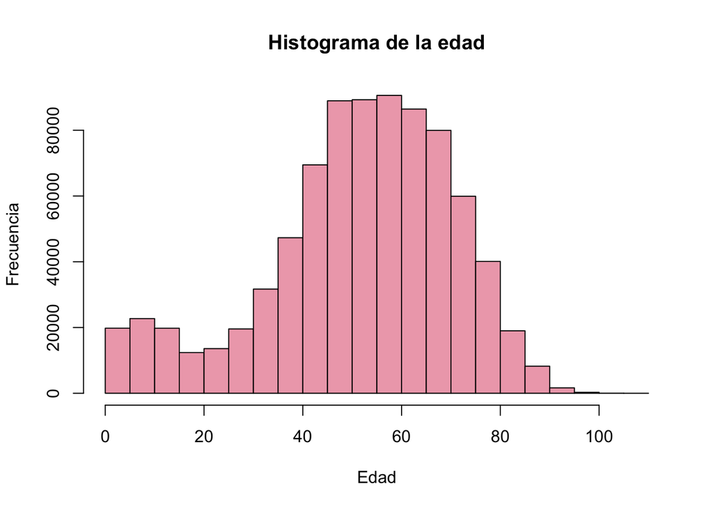

```r
hist(datafonco$EDAD,main='Histograma de la edad',xlab='Edad',ylab='Frecuencia',col='pink2')
```

**Tabla de atenciones por grupo de diagnósticos (sexo: femenino):**

```r
datafonco %>%
filter(SEXO == "FEMENINO") %>%
group_by(GRUPO_DIAGNOSTICOS) %>%
summarise(Cant_atenciones = n()) %>%
mutate(Porcentaje = scales::percent(Cant_atenciones/ sum(Cant_atenciones)))
```

```
## # A tibble: 6 × 3
##   GRUPO_DIAGNOSTICOS       Cant_atenciones Porcentaje
##   <chr>                              <int> <chr>
## 1 CANCER DE COLON                    28545 4.776%
## 2 CANCER DE CUELLO UTERINO          148582 24.859%
## 3 CANCER DE ESTOMAGO                 28324 4.739%
## 4 CANCER DE MAMA                    298104 49.875%
## 5 LEUCEMIA                           51156 8.559%
## 6 LINFOMA                            42986 7.192%
```

Los dos tipos de cánceres con más atenciones en la mujer son: cáncer de mama (49.88%) y cáncer de cuello uterino (24.86%)

**Tabla de atenciones por grupo de diagnósticos (sexo: masculino):**

```r
datafonco %>%
filter(SEXO == "MASCULINO") %>%
group_by(GRUPO_DIAGNOSTICOS) %>%
summarise(Cant_atenciones = n()) %>%
mutate(Porcentaje = scales::percent(Cant_atenciones/ sum(Cant_atenciones)))
```

```
## # A tibble: 6 × 3
##   GRUPO_DIAGNOSTICOS Cant_atenciones Porcentaje
##   <chr>                        <int> <chr>
## 1 CANCER DE COLON              22739 10.2%
## 2 CANCER DE ESTOMAGO           26944 12.1%
## 3 CANCER DE MAMA                1797 0.8%
## 4 CANCER DE PROSTATA           71649 32.1%
## 5 LEUCEMIA                     60824 27.3%
## 6 LINFOMA                      39025 17.5%
```

En el caso de los hombres, los cánceres con más atenciones son: cáncer de próstata (32.1%),leucemia (27.3%)y linfoma(17.5%).

**Tabla de atenciones por grupo de edades para el sexo femenino:**

```r
datafonco %>%
  filter(SEXO == "FEMENINO") %>%
  mutate(EDAD_grupo = cut(EDAD, breaks = seq(0, max(EDAD), length.out = 11), labels = c("0-10", "11-20", "21-30", "31-40", "41-50", "51-60", "61-70", "71-80", "81-90", "91+"), include.lowest = TRUE, right = TRUE)) %>%
  group_by(EDAD_grupo) %>%
  summarise(count = n()) %>%
  mutate(porcentaje = scales::percent(count/sum(count))) #Para que salga con el símbolo %
```

```
## # A tibble: 10 × 3
##    EDAD_grupo  count porcentaje
##    <fct>       <int> <chr>
##  1 0-10        18090 3.03%
##  2 11-20       13982 2.34%
##  3 21-30       24317 4.07%
##  4 31-40       85018 14.22%
##  5 41-50      165050 27.61%
##  6 51-60      146740 24.55%
##  7 61-70      105508 17.65%
##  8 71-80       33158 5.55%
##  9 81-90        5716 0.96%
## 10 91+           118 0.02%
```

En el caso de las mujeres, la edad predominante se encuentra en un rango de 41-50 años con un 27.61% y otro grupo considerable es 51-60 años con un 24.55%.

**Tabla de atenciones por grupo de edades para el sexo masculino:**

```r
datafonco %>%
  filter(SEXO == "MASCULINO") %>%
  mutate(EDAD_grupo = cut(EDAD, breaks = seq(0, max(EDAD), length.out = 11), labels = c("0-10", "11-20", "21-30", "31-40", "41-50", "51-60", "61-70", "71-80", "81-90", "91+"), include.lowest = TRUE, right = TRUE)) %>%
  group_by(EDAD_grupo) %>%
  summarise(count = n()) %>%
  mutate(porcentaje = scales::percent(count/sum(count))) #Para que salga con el símbolo %
```

```
## # A tibble: 10 × 3
##    EDAD_grupo count porcentaje
##    <fct>      <int> <chr>
##  1 0-10       24405 10.95%
##  2 11-20      19141 8.58%
##  3 21-30      12673 5.68%
##  4 31-40      12089 5.42%
##  5 41-50      20204 9.06%
##  6 51-60      32046 14.37%
##  7 61-70      49614 22.25%
##  8 71-80      43964 19.72%
##  9 81-90       8452 3.79%
## 10 91+          390 0.17%
```

Para el caso de los hombres, el rango de edad con mayor atención por cáncer es 61-70 años con un 22.25% y 71-80 años con un 19.72%.

**Monto bruto por grupo de diagnóstico para los hombres:**

```r
  datafonco %>%
  filter(SEXO == 'MASCULINO') %>%
  group_by(GRUPO_DIAGNOSTICOS) %>%
  summarise(SUMA_MONTO_BRUTO = sum(MONTO_BRUTO))
```

```
## # A tibble: 6 × 2
##   GRUPO_DIAGNOSTICOS SUMA_MONTO_BRUTO
##   <chr>                         <dbl>
## 1 CANCER DE COLON            6824917.
## 2 CANCER DE ESTOMAGO         7335195.
## 3 CANCER DE MAMA              286150.
## 4 CANCER DE PROSTATA         9211449.
## 5 LEUCEMIA                  42425768.
## 6 LINFOMA                   12978532.
```

Para los hombres, se puede observar que el monto total de la prestación oncológica es superior en los cánceres de leucemia y linfoma.

**Monto bruto por grupo de diagnósticos para las mujeres:**

```r
  datafonco %>%
  filter(SEXO == 'FEMENINO') %>%
  group_by(GRUPO_DIAGNOSTICOS) %>%
  summarise(SUMA_MONTO_BRUTO = sum(MONTO_BRUTO))
```

```
## # A tibble: 6 × 2
##   GRUPO_DIAGNOSTICOS       SUMA_MONTO_BRUTO
##   <chr>                               <dbl>
## 1 CANCER DE COLON                  7514173.
## 2 CANCER DE CUELLO UTERINO        24567400.
## 3 CANCER DE ESTOMAGO               7107455.
## 4 CANCER DE MAMA                  40937933.
## 5 LEUCEMIA                        36634367.
## 6 LINFOMA                         10454769.
```

En tanto que para las mujeres, los cánceres con mayor monto total en la prestación oncológica son el cáncer de mama y la leucemia.

**Boxplot de las edades por sexo:**

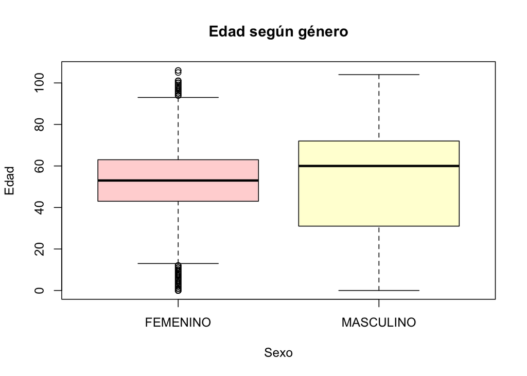

```r
boxplot(datafonco$EDAD ~ datafonco$SEXO,
        main = "Edad según género",
        ylab = "Edad",
        xlab = "Sexo",
        col = rainbow(6, alpha=0.2))
```

En el gráfico, se puede observar que la edad para los hombres se encuentra más dispersa por lo que la distribución es menos uniforme.

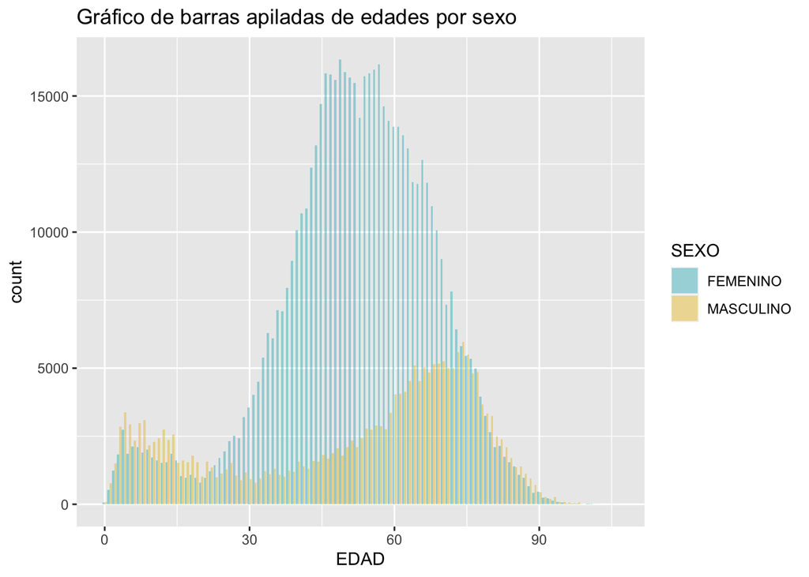

```r
ggplot(datafonco, aes(x = EDAD, fill = SEXO)) +
  geom_bar(stat = "count", position = "dodge", alpha = 0.4) +
  scale_fill_manual(values = c("#00AFBB", "#E7B800")) +
  labs(title = "Gráfico de barras apiladas de edades por sexo")
```

**Barplot del grupo de diagnósticos:**

```r
frecuencias <- table(datafonco$GRUPO_DIAGNOSTICOS)
frecuencias
```

```
##
##          CANCER DE COLON CANCER DE CUELLO UTERINO       CANCER DE ESTOMAGO
##                    51284                   148582                    55268
##           CANCER DE MAMA       CANCER DE PROSTATA                 LEUCEMIA
##                   299901                    71649                   111980
##                  LINFOMA
##                    82011
```

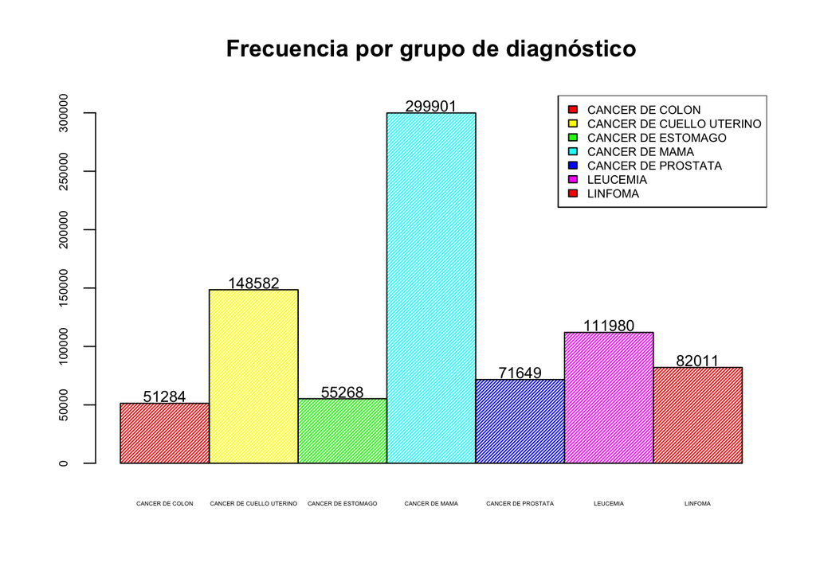

```r
fg <- barplot(frecuencias,
              col = rainbow(6),
              space = 0,
              density = 50,
              ylim = c(0, max(frecuencias) + 15000),
              cex.axis = 0.6,
              cex.names = 0.3,
              )
legend("topright",rownames(frecuencias),text.font=1,cex=0.6,fill=rainbow(6))
text(x = fg, y = frecuencias + 6000, labels = frecuencias, cex = 0.8)
title("Frecuencia por grupo de diagnóstico")
```

*Nota:*

1. Cex: Este parámetro controla el tamaño relativo de los caracteres en un gráfico. cex significa “Character Expansion” (Expansión de caracteres) y es un multiplicador que ajusta el tamaño de todos los caracteres en el gráfico, incluidos los textos en las etiquetas de ejes, títulos, leyendas y cualquier otro texto que se pueda agregar al gráfico.
2. text.font: Este parámetro controla el estilo de la fuente del texto en la leyenda. Puede tomar valores enteros de 1 a 5, donde 1 significa texto normal, 2 significa texto en negrita, 3 significa texto en cursiva, 4 significa texto subrayado y 5 significa texto tachado.

**Barplot de los grupos de diagnósticos del sexo femenino:**

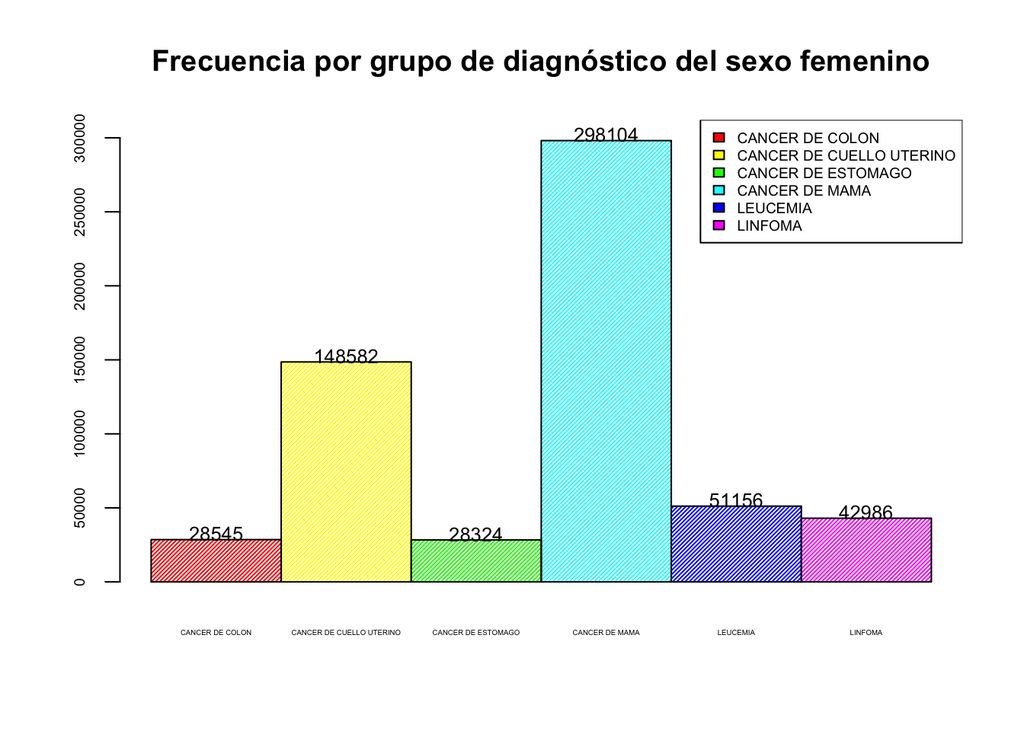

```r
data_filtrados <- subset(datafonco, SEXO == 'FEMENINO')
frecuencias2 <- table(data_filtrados$GRUPO_DIAGNOSTICOS)

fg <- barplot(frecuencias2,
              col = rainbow(6),
              space = 0,
              density = 50,
              ylim = c(0, max(frecuencias2) + 14000),
              cex.axis = 0.6,
              cex.names = 0.3,
              )

legend("topright", rownames(frecuencias2), text.font = 1, fill = rainbow(6), cex = 0.6)
text(x = fg, y = frecuencias2 + 4000, labels = frecuencias2, cex = 0.8)
title("Frecuencia por grupo de diagnóstico del sexo femenino")
```

**Gráfico con ggplot (otra forma):**

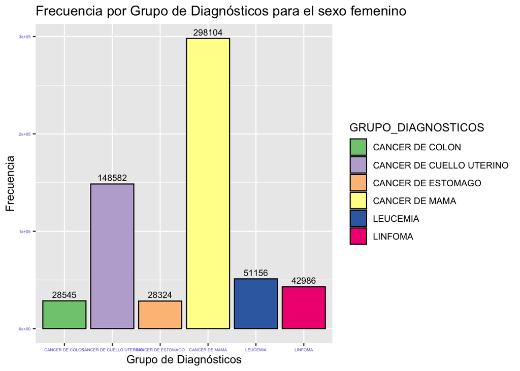

```r
ggplot(data_filtrados,aes(x = GRUPO_DIAGNOSTICOS,fill = GRUPO_DIAGNOSTICOS)) +
geom_bar(position = "dodge", color = "black") +
geom_text(stat='count',aes(label = after_stat(count)), vjust = -0.5, size = 3) +
labs(title = "Frecuencia por Grupo de Diagnósticos para el sexo femenino", x = "Grupo de Diagnósticos", y = "Frecuencia") +
theme(axis.text = element_text(color = "slateblue", size = 4)) + scale_fill_brewer(palette = "Accent")
```

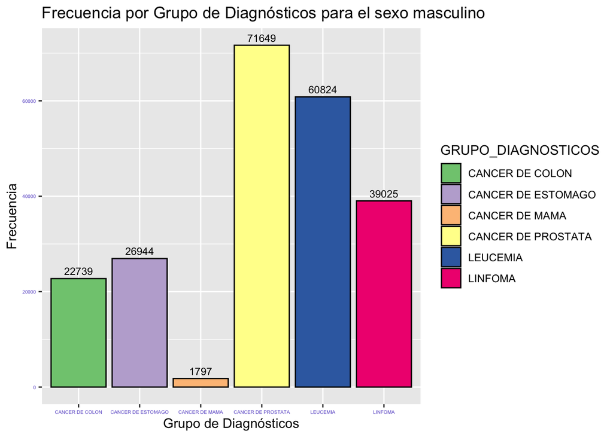

```r
data_filtrados_m <- subset(datafonco, SEXO == 'MASCULINO')
frecuencias3 <- table(data_filtrados_m$GRUPO_DIAGNOSTICOS)

ggplot(data_filtrados_m,aes(x = GRUPO_DIAGNOSTICOS,fill = GRUPO_DIAGNOSTICOS)) +
geom_bar(position = "dodge", color = "black") +
geom_text(stat='count',aes(label = after_stat(count)), vjust = -0.5, size = 3) +
labs(title = "Frecuencia por Grupo de Diagnósticos para el sexo masculino", x = "Grupo de Diagnósticos", y = "Frecuencia") +
theme(axis.text = element_text(color = "slateblue", size = 4)) +
  scale_fill_brewer(palette = "Accent")
```

**Otra forma:**

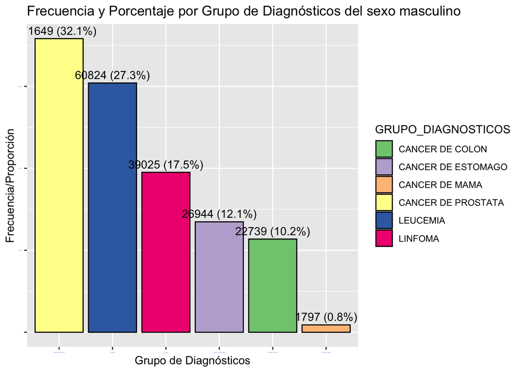

```r
datafonco %>%
  filter(SEXO == 'MASCULINO') %>%
  group_by(GRUPO_DIAGNOSTICOS) %>%
  summarise(count = n()) %>%
  mutate(porc = round(count/sum(count) * 100, 2)) %>%
  ggplot(aes(x = reorder(GRUPO_DIAGNOSTICOS, -count), y = count,fill=GRUPO_DIAGNOSTICOS)) +
  geom_bar(stat = "identity", position = "dodge", color = "black") +
  geom_text(aes(label = paste(count, " (", scales::percent(porc/100), ")", sep = "")), vjust = -0.5, position = position_dodge(width = 0.9)) +
  labs(title = "Frecuencia y Porcentaje por Grupo de Diagnósticos del sexo masculino",
       x = "Grupo de Diagnósticos",
       y = "Frecuencia/Proporción") +
theme(axis.text = element_text(color = "slateblue", size = 1)) +
  scale_fill_brewer(palette = "Accent")
```

**Monto bruto por grupo de diagnosticos - Hombres:**

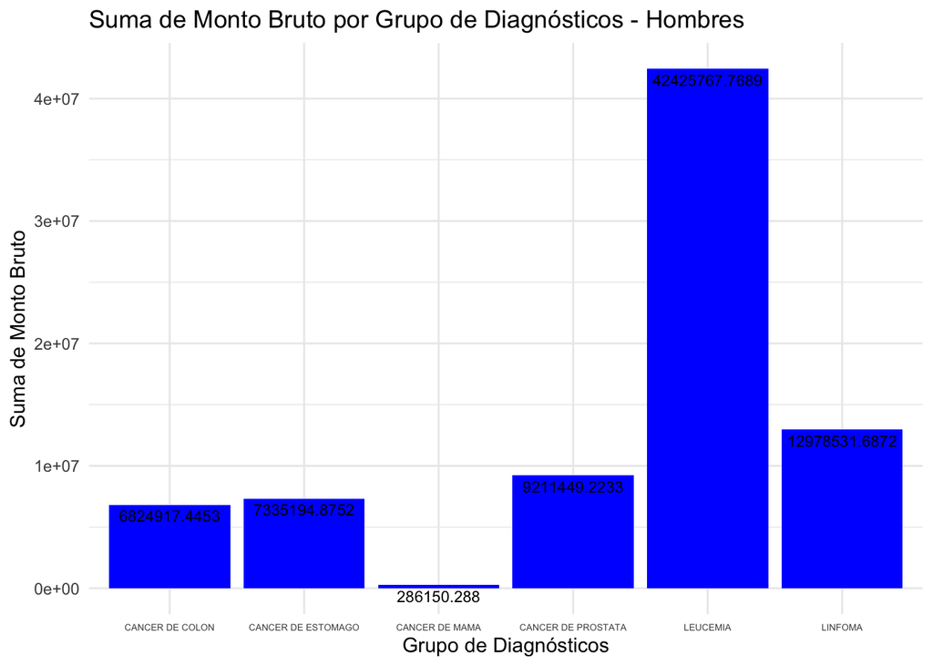

```r
data_summa <- datafonco %>%
  filter(SEXO == 'MASCULINO') %>%
  group_by(GRUPO_DIAGNOSTICOS) %>%
  summarise(SUMA_MONTO_BRUTO = sum(MONTO_BRUTO))

ggplot(data_summa, aes(x = GRUPO_DIAGNOSTICOS, y = SUMA_MONTO_BRUTO)) +
  geom_bar(stat = "identity", fill = "blue", position = position_dodge()) +
  geom_text(
    aes(label = SUMA_MONTO_BRUTO, x = GRUPO_DIAGNOSTICOS, hjust = 0.5, vjust = 1.5),
    color = "black",
    cex = 3
  ) +
  labs(title = "Suma de Monto Bruto por Grupo de Diagnósticos - Hombres",
       x = "Grupo de Diagnósticos",
       y = "Suma de Monto Bruto") +
  theme_minimal() +
  theme(axis.text.x = element_text(size = 5)) # Cambiar el tamaño del eje x
```

**Monto bruto por grupo de diagnosticos - Mujeres:**

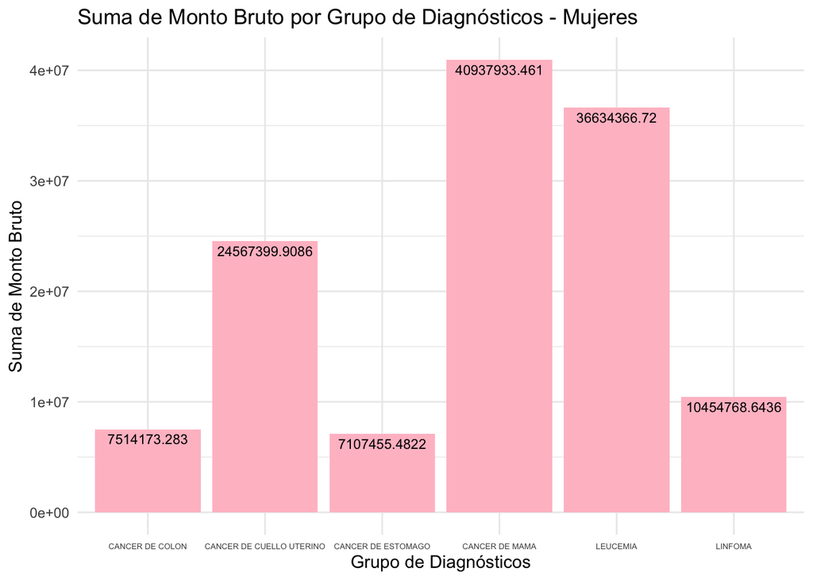

```r
data_sumfe <- datafonco %>%
  filter(SEXO == 'FEMENINO') %>%
  group_by(GRUPO_DIAGNOSTICOS) %>%
  summarise(SUMA_MONTO_BRUTO = sum(MONTO_BRUTO))

ggplot(data_sumfe, aes(x = GRUPO_DIAGNOSTICOS, y = SUMA_MONTO_BRUTO)) +
  geom_bar(stat = "identity", fill = "pink", position = position_dodge() ) +
  geom_text(
    aes(label = SUMA_MONTO_BRUTO, x = GRUPO_DIAGNOSTICOS, hjust = 0.5, vjust = 1.5),
    color = "black",
    cex = 3
  ) +
  labs(title = "Suma de Monto Bruto por Grupo de Diagnósticos - Mujeres",
       x = "Grupo de Diagnósticos",
       y = "Suma de Monto Bruto") +
  theme_minimal() +
  theme(axis.text.x = element_text(size = 5)) # Cambiar el tamaño del eje x
```

**Principales insights obtenidos del análisis**

1. **Volumen y estructura de los datos**
- Se analizaron 820,675 registros correspondientes a atenciones oncológicas.
2. **Distribución por sexo**
- Mujeres: predominan los casos de cáncer de mama (49.9%) y cáncer de cuello uterino (24.8%).
- Hombres: los más frecuentes son cáncer de próstata (32.1%), leucemia (27.3%) y linfoma (17.5%).
3. **Distribución por grupos de edad**
- En mujeres, los grupos de edad con mayor atención son 41-50 años (27.6%) y 51-60 años (24.6%).
- En hombres, los rangos predominantes son 61-70 años (22.2%) y 71-80 años (19.7%).
4. **Gasto en prestaciones oncológicas**
- En mujeres, los mayores montos están asociados a cáncer de mama (aprox 40.9 millones) y leucemia (aprox 36.6 millones).
- En hombres, destacan leucemia (aprox 42.4 millones) y linfoma (aprox 13 millones).
- Los tipos de cáncer hematológicos generan el mayor costo de atención en ambos sexos.
5. **Distribución de edades por sexo**
- El boxplot muestra que la edad de los hombres es más dispersa, indicando una mayor variabilidad en los rangos etarios de atención frente a las mujeres.